# Democracy and Autocratization 2

Final Project Essentials: Interaction Terms

Carolina Torreblanca

University of Pennsylvania

**Global Development**: Intermediate Topics in Politics, Policy, and Data

PSCI 3200 - Spring 2026

# Logistics

## Assignments

- Today
  - [VDem (2024); pages 9-45](https://v-dem.net/documents/43/v-dem_dr2024_lowres.pdf) ([Interactive visualization](https://episodes.shinyapps.io/validation/))
  - Garcia-Ponce and Wantchekon (2023)
- Thursday (3/14)
  - Hassan et al. (2022)
  - Lebas and Young (2023)

## Agenda

1. V-Dem
2. Garcia-Ponce and Wantchekon
3. Final Project Essentials: Interaction terms

# Varieties of Democracy

## Polyarchy (Dahl, 1972)

**Polyarchy is about the degree of political competition**

- Democracy is an ideal too tough to define
- Instead, he describes procedures that make countries more/less democratic
- Contestation and inclusiveness allow for competition over power
- Competition makes governments accountable to citizens

## Polyarchy (Dahl, 1972)

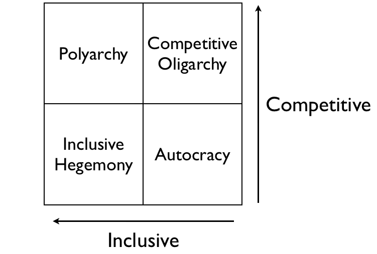

## Polyarchy (Dahl, 1972)

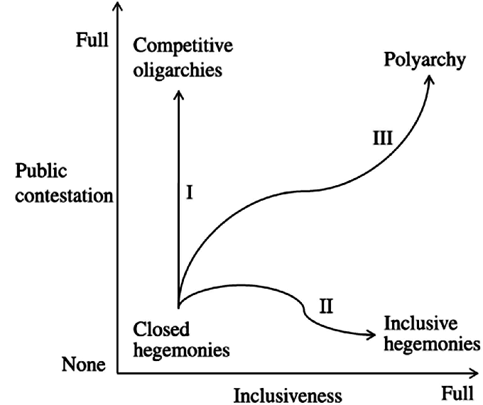

## Benefits of Democracy

**Causal effects of regime-type are difficult, but…**

- Higher economic growth
- Lower poverty (famines)
- Fewer international conflicts

## Waves of Democracy

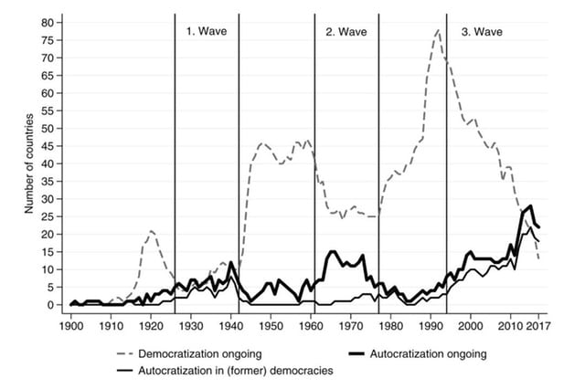

## Varieties of Democracy

- Governance characteristics scored based on expert opinion
- 25 country experts (2/3 local and 1/3 foreign)
- 500+ indicators
- Sophisticated methods of aggregating into indices and estimating uncertainty across coders
- Liberal Democracy, Electoral Democracy, Electoral Autocracy, Autocracy

## Varieties of Democracy

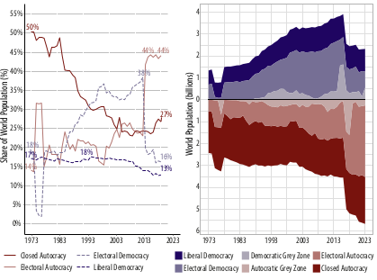

## How is governance changing?

**Ongoing transitions across regions**

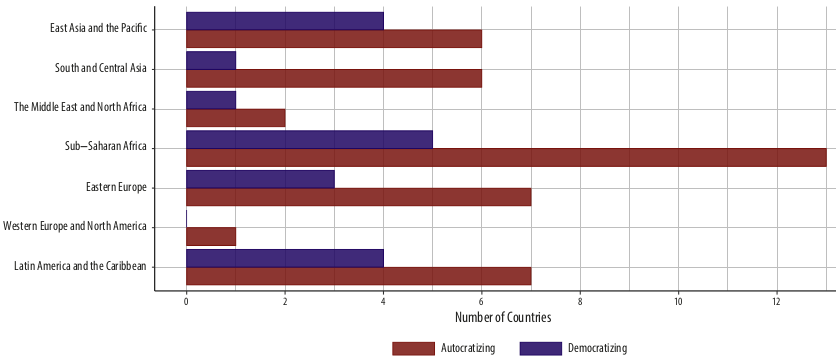

## How is governance changing?

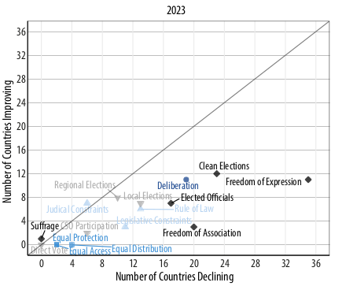

## How is governance changing?

**Most deterioration seen on:**

1. Freedom of expression
2. Clean elections
3. Freedom of association

## How is governance changing?

**Broad trends**

- Number of people living under autocracy back to 1985 levels
- Concentration of global power is shifting (BRICS+ vs G7)
- 60 countries are holding national elections this year
  - 31 worsening; 3 improving

**What did you find interesting?**

## Critiques of VDem: Little & Meng

**Incumbents are losing elections**

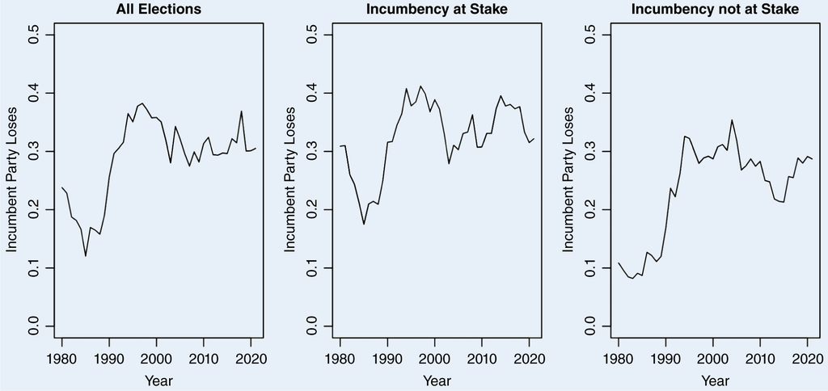

## Critiques of VDem: Little & Meng

**Incumbents are losing elections**

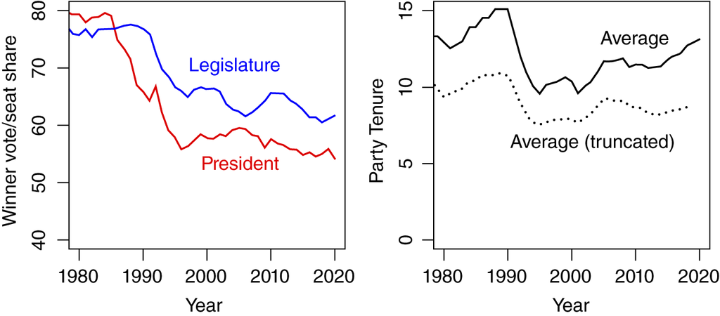

## Critiques of VDem: Little & Meng

**Mixed evidence on attacks on journalists**

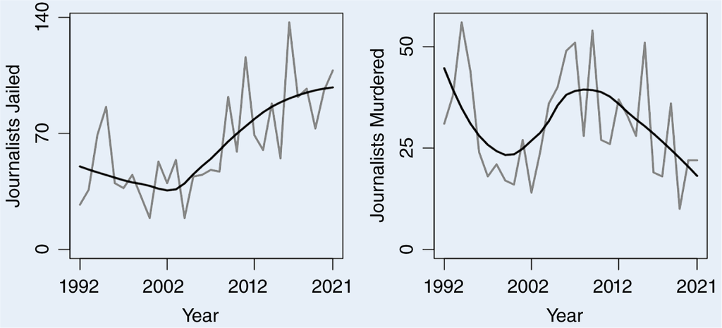

## Defense of VDem

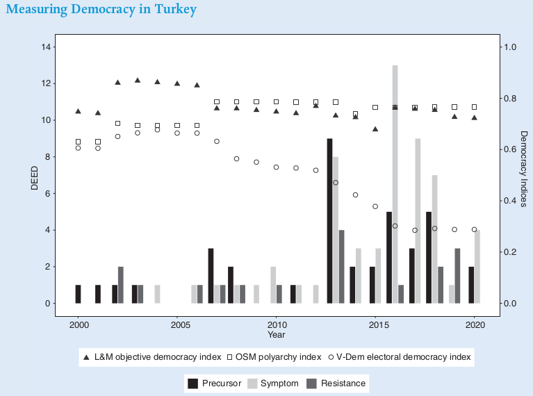

## Defense of VDem

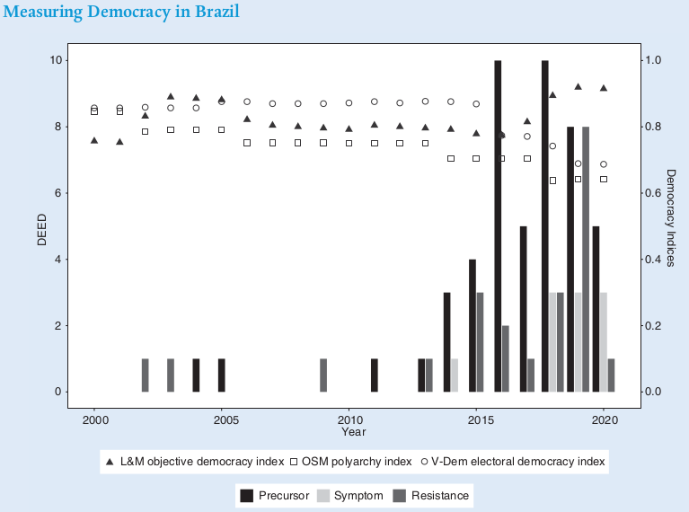

## Defense of VDem

**Lots of new anti-NGO laws**

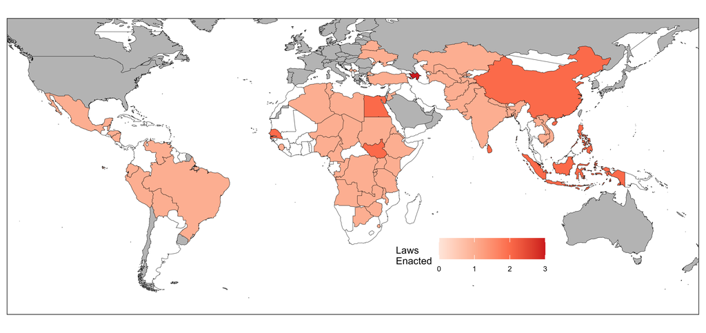

# Garcia-Ponce and Wantchekon

## Why countries Democratize

- Correlation between income and democracy
  - Modernization theory: wealth, education, and urbanization are associated with democratization
- Why might this be true?

*In Africa, democratization after the Cold War was shaped by the level of development (urbanization) at the start of countries’ anti-colonial movements*

## Context

- Anti-colonial movements chose between two strategies:
  - Rural insurgency
  - Urban protest
- Democratization was delayed by the Cold War
1. *What shaped opposition movements’ choice between strategies?*
2. *What delayed democratization during the Cold War?*

## Theory

**Why does opposition strategy affect democratization decades later?**

- Inclusion
- Organization

**Mechanisms:**

- Institutions
- Behaviors

## Findings

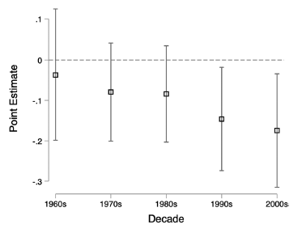

## Threats to inference

- Things that affect whether or not opposition uses insurgency vs protest might also affect current levels of democracy

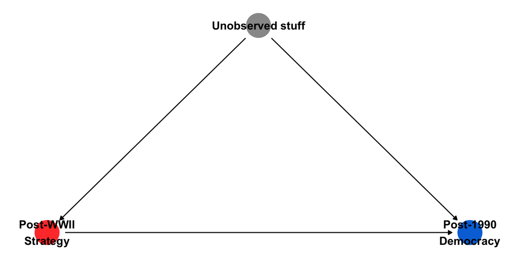

## Identification

- Covariates
- Sensitivity analysis
- Difference-in-Differences
  - Leverages changes within countries over time
  - Before the end of the cold war, groups look similar
  - After the end of the cold war, groups trend away from each other
- Instrumental Variables
  - Leverages ‘plausibly exogeneous’ variation in terrain
  - Terrain predicts strategy choice

## Instrumental Variable

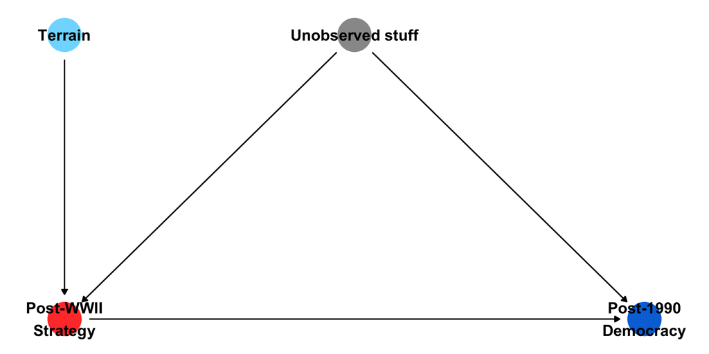

## Mechanisms: Institutions

**We do not seen an impact of Post-WWII Opposition Strategy on Post-1990 Institutions**

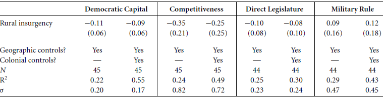

## Mechanisms: Behavior

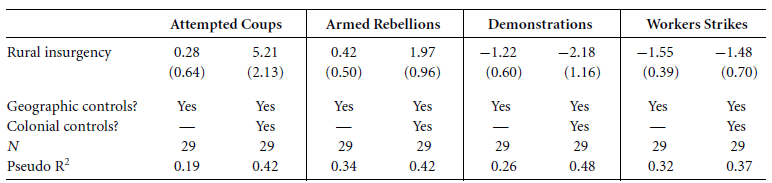

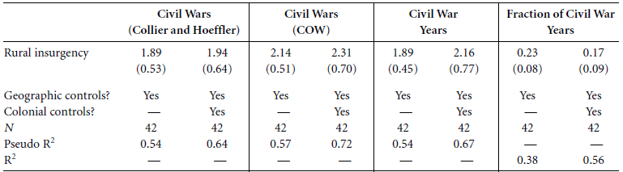

## Policy Implications

- Historical social movements help understand the link between structural conditions and democratic development
- Non-violent collective action appears critical for the establishment of lasting democracy

# Final Project Essentials

## Interaction Terms

**What is an interaction term?**

- Simple linear models assume that the effect of predictors is independent of other factors
- Interaction terms allow us to estimate the difference in the slope of a predictor across unit characteristics

$$Y_i = \alpha + \beta_1 X_{i1} + \beta_2 X_{i2} + \beta_3 X_{i1}*X_{i2} + \epsilon_i$$

## Interaction Terms

**What are interaction terms used for?**

- Heterogeneous effects
- Difference-in-differences

**Example:** Continuous outcome with two binary predictors

- $\alpha$: Intercept when $X_{i1}$ and $X_{i2}$ are 0
- $\beta_1$ Slope when $X_{i2} = 0$
- $\beta_2$ Difference in $\alpha$ between $X_{i2}=0$ and $X_{i2}=1$
- $\beta_3$ Difference in $\beta_1$ between $X_{i2}=0$ and $X_{i2}=1$

https://carolina-torreblanca.github.io/psci3200-globaldev-main/